# EDA

## Variable Descriptions

Patient_ID Unique anonymized identifier per patient Visit_Number Sequential clinical visit index Visit_Timestamp Date of each visit Scan_Type Type of scan performed (Ultrasound, FNA, Elastography) Age, Gender, Height, Weight, BMI Basic demographics and body metrics Family_History Binary indicator for thyroid disease in family history Smoking_Status Categorical: Smoker, Non-Smoker, Former Smoker Radiation_Exposure Prior exposure to radiation therapy or sources Nodule_Size_mm, Margin_Sharpness, Shape_Score, Echogenicity_Index Radiomic features from scans

Calcification_Presence, Capsular_Invasion_Indicator Structural indicators linked to malignancy

Vascularity_Score, Texture_Entropy, Asymmetry_Score Advanced scan-derived imaging biomarkers

TSH_Risk_Level, TPOAb_Probability, Thyroglobulin_Level_Predicted, Calcitonin_Level_Predicted, Reverse_T3_Index Hormonal indicators Heart_Rate, Daily_Steps, Sleep_Patterns, Body_Temperature, Pulse_Oximetry Smart device vitals

Stress_Level, Symptom_Onset_Duration, Hormonal_Change_Rate, Medication_Adherence Behavioral and progression indicators

Diagnosis_Label Binary classification (0: Benign, 1: Malignant) Cancer_Type Categorical subtype (e.g., Papillary, Follicular, Medullary, etc.)

Recurrence_Risk Binary risk estimation for recurrence likelihood

```r
library(glmnet)
```

```r
patient_freq =
  thyro %>%
  group_by(Patient_ID) %>%
  summarize(n = n())

patient_freq4 = patient_freq %>%
  filter(n >= 4)

patient_freq4 = patient_freq4$Patient_ID

thyro4 =
  thyro %>%
  filter(Patient_ID %in% patient_freq4) %>%
  group_by(Patient_ID) %>%
  mutate(
    across(c(4, 6, 10, 11, 12, 17, 21, 22, 35, 36, 37, 38) - 1, as.factor)
  )  %>%
  mutate(
    elapsed_time_days = as.numeric((Visit_Timestamp - min(Visit_Timestamp)))
  ) %>%
  ungroup() %>%
  mutate(ID = as.numeric(factor(Patient_ID)))
```

```r
L1 = list(
thyro4 %>%
  ggplot(aes(
    x = Thyroglobulin_Level_Predicted,
  )) +
  geom_density(alpha = 0.50,
               fill = "purple3",
               adjust = 2) +
  xlab("Tg not transformed")
,
thyro4 %>%
  ggplot(aes(
    x = Calcitonin_Level_Predicted
  )) +
  geom_density(alpha = 0.50,
               fill = "purple3",
               adjust = 2) +
  xlab("Ct not transformed")
,
thyro4 %>%
  ggplot(aes(
    x = Reverse_T3_Index
  )) +
  geom_density(alpha = 0.50,
               fill = "purple3",
               adjust = 2) +
  xlab("rT3 as is")
)
```

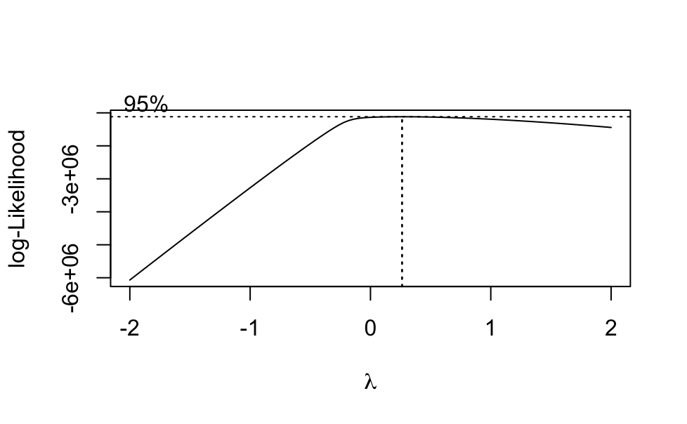

```r
m1 <- lm(Thyroglobulin_Level_Predicted + 1e-6 ~ 1, data = thyro4)
bc1 = MASS::boxcox(m1, plotit = TRUE)
```

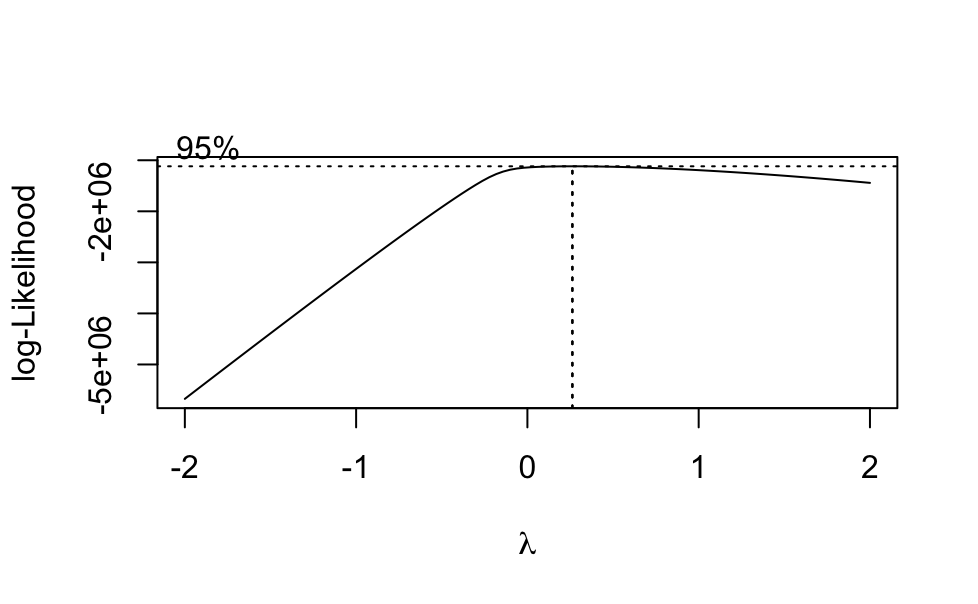

```r
optLamda_tg = bc1$x[which.max(bc1$y)]


m2 <- lm(Calcitonin_Level_Predicted + 1e-6 ~ 1, data = thyro4)
bc2 = MASS::boxcox(m2, plotit = TRUE)
```

```r
optLambda_calc = bc2$x[which.max(bc2$y)]

thyro4 = thyro4 %>%
  mutate(
    `TgT` =
      ((Thyroglobulin_Level_Predicted + 1e-6)^0.25 - 1) / 0.25,
    `CtT` = ((Calcitonin_Level_Predicted + 1e-6)^0.25 -1) / 0.25,
    rT3 = Reverse_T3_Index
  )

rm(optLambda_calc, optLamda_tg, bc1, bc2, m1, m2)
```

#### Exploratory Data Analysis

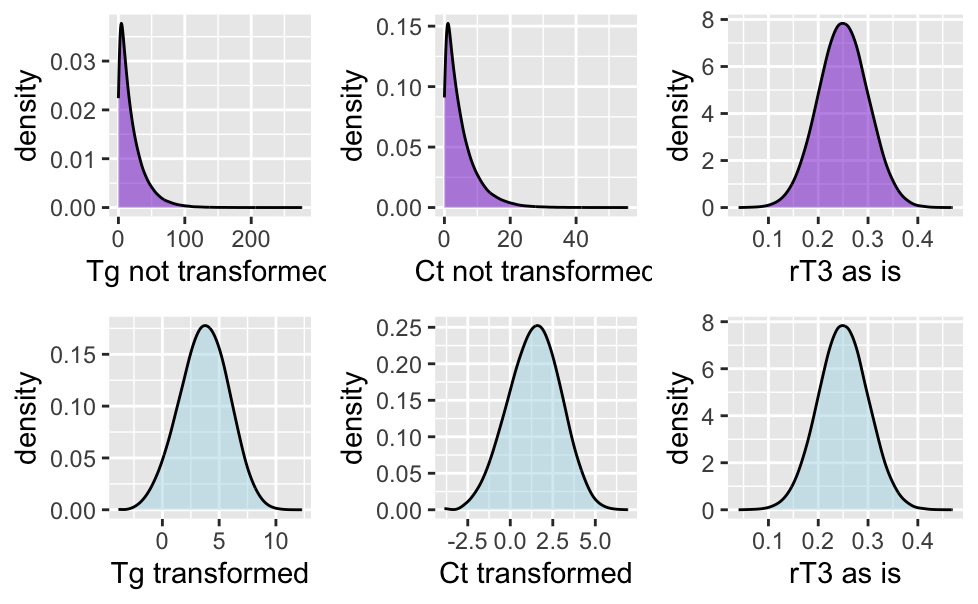

```r
L2 =
list(thyro4 %>%
  ggplot(aes(
    x = TgT,
  )) +
  geom_density(alpha = 0.50,
               fill = "lightblue",
               adjust = 2)+
    xlab("Tg transformed")
,
thyro4 %>%
  ggplot(aes(
    x = CtT
  )) +
  geom_density(alpha = 0.50,
               fill = "lightblue",
               adjust = 2)+
  xlab("Ct transformed")
,
thyro4 %>%
  ggplot(aes(
    x = rT3
  )) +
  geom_density(alpha = 0.50,
               fill = "lightblue",
               adjust = 2) +
  xlab("rT3 as is")
)

plot_grid(plotlist = c(L1, L2))
```

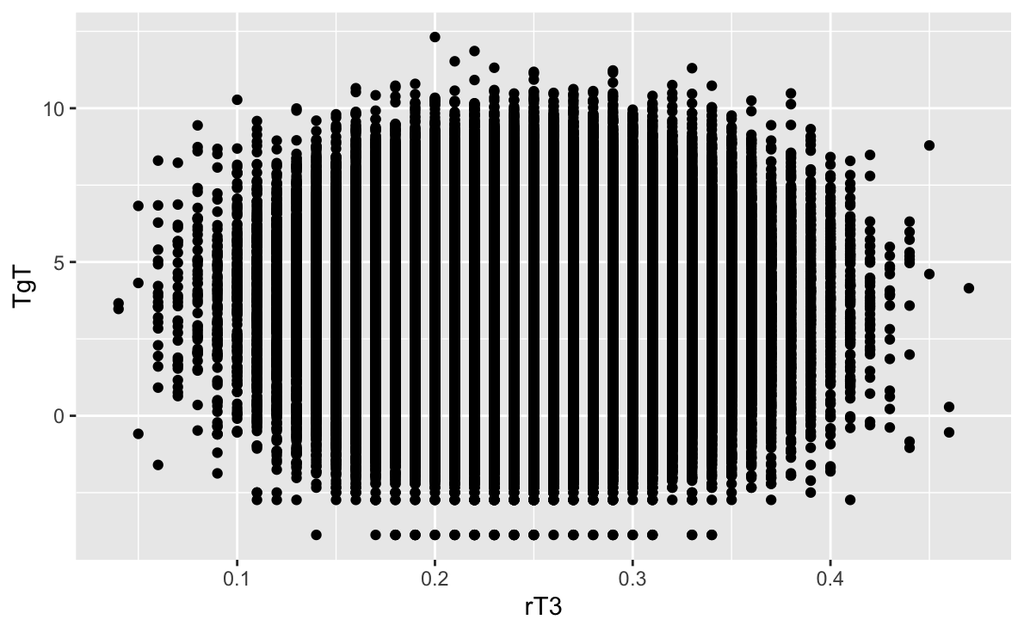

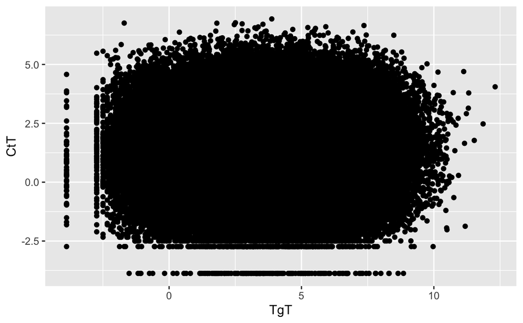

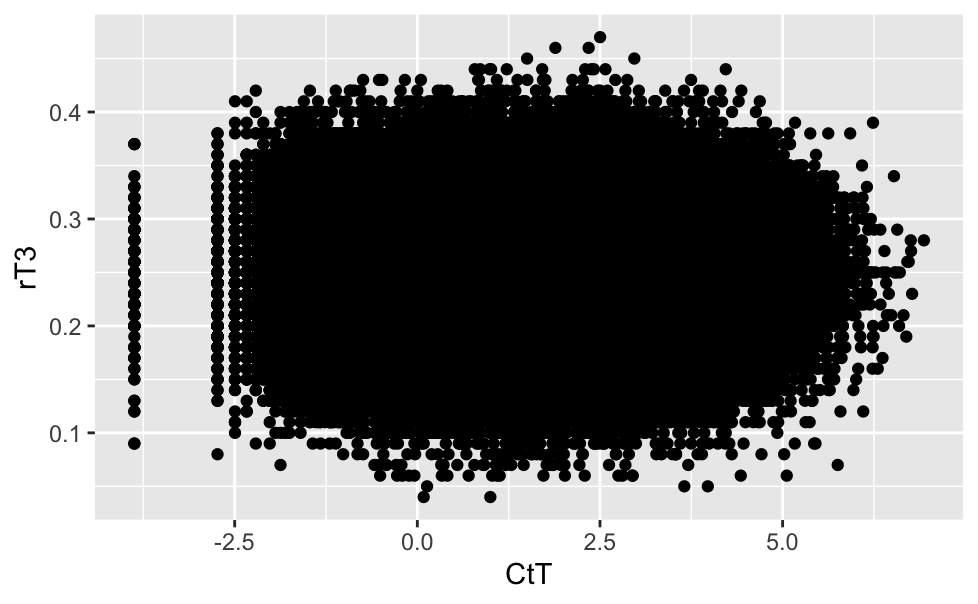

```r
list(thyro4 %>%
  ggplot(aes(x = rT3, y = TgT)) +
  geom_point()
,
thyro4 %>%
  ggplot(aes(x = TgT, y = CtT)) +
  geom_point()
,
thyro4 %>%
  ggplot(aes(x = CtT, y = rT3)) +
  geom_point())
```

```r
list(
  cor(thyro4$rT3, thyro4$CtT),
  cor(thyro4$rT3, thyro4$TgT),
  cor(thyro4$TgT, thyro4$CtT)
)
```

```
[[1]]
[1] -0.001178221

[[2]]
[1] 0.000561061

[[3]]
[1] 0.00102506
```

Completely uncorrelated!